# (Borrower characteristics that affects Borrower APR)

## by (Ali Nasser Mohamed)

## Investigation Overview

> In this investigation, I wanted to look at Borrower characteristics that affects Borrower APR and which People take loans from prosper

## Dataset Overview

> This data set contains 113,937 loans with 81 variables on each loan, including loan amount, borrower rate (or interest rate), current loan status, borrower income, and many others

## (the distibution of our main feature(Borrower APR))

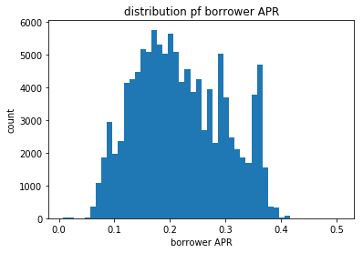

## (which kind of people go and take aloan from prosper)

> we found that most of people who takes loans is employed ones

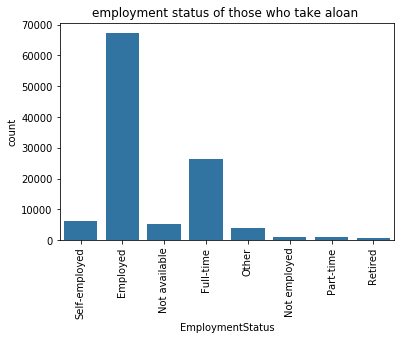

## (Borrower APR for high and low terms &How term is related to original loan amount )

we found that high amount of loan will be taken on a large term as we expect that increasing the term will increase the BorrowerAPR but we found alse that at higher terms the mean of BorrowerAPR decreases which need more investigations that we will see later in our presentation

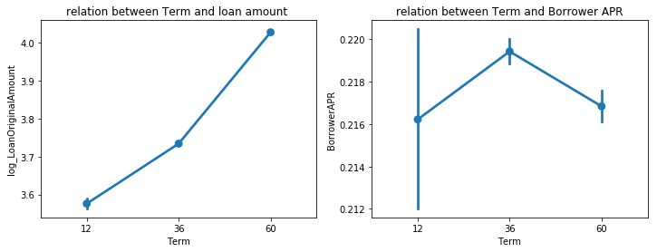

## ( the effect of Employment Status and Is Borrower Homeowner on BorrowerAPR)

being employed and have gome make the APR becomes lower that may be the prosrer consier the employed ones more consident and give them high prosper rate

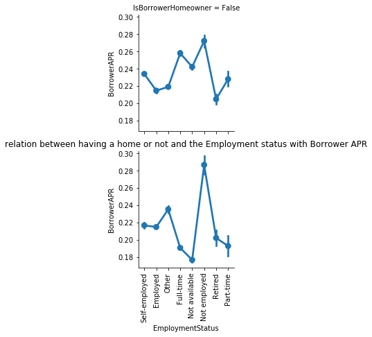

## the effect of both original amount of loan and Term on APR

we now could understand why the mean of borrower APR become smaller with increase in term that happens because loans of high terms has a very high original laon amount and with incrasing the original amount the Borrower APR become smaller

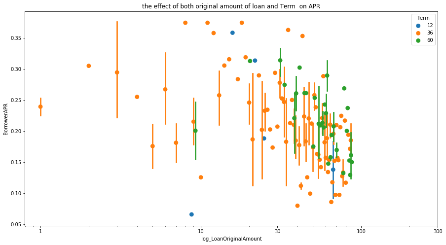